# Data Cleaning & EDA

2024-11-15

# Data Cleaning

```r
# Read the data
sales.zipcodes <- read.csv("project.sales.zipcodes.csv")
sales.cities <- read.csv("project.sales.cities.csv")
sales.counties <- read.csv("project.sales.counties.csv")

acs.zipcodes <- read.csv("project.acs.zipcodes.csv")
acs.cities <- read.csv("project.acs.cities.csv")
acs.counties <- read.csv("project.acs.counties.csv")
```

```r
# Merge data for country, city and zipcode levels
counties_data <- sales.counties %>%
  left_join(acs.counties, by = "county") %>%
  # Convert 'county' and 'category' to factors
  mutate(across(c(county, category), as.factor))

cities_data <- sales.cities %>%
  left_join(acs.cities, by = "city") %>%
  # Convert 'city' and 'category' to factors
  mutate(across(c(city, category), as.factor))

zipcodes_data <- sales.zipcodes %>%
  left_join(acs.zipcodes, by = "zipcode") %>%
  # Convert 'zipcode' and 'category' to factors
  mutate(across(c(zipcode, category), as.factor))
```

```r
# Define function to check for missing values
missing_check <- function(data){
  missing_count = data %>%
    summarise(across(everything(), ~ sum(is.na(.))))
  print(missing_count)
}

# Find count of missing values
missing_check(counties_data)
```

```
##   county category sale.dollars sale.volume high.school bachelor unemployment
## 1      0        0            0           0          10       10           10
##   income population pop.white pop.black pop.indian pop.asian pop.hawai
## 1     10         10        10        10         10        10        10
##   pop.other pop.multi
## 1        10        10
```

```r
missing_check(cities_data)
```

```
##   city category sale.dollars sale.volume high.school bachelor unemployment
## 1    0        0            0           0          60       60           60
##   income population pop.white pop.black pop.indian pop.asian pop.hawai
## 1     60         60        60        60         60        60        60
##   pop.other pop.multi
## 1        60        60
```

```r
missing_check(zipcodes_data)
```

```
##   zipcode category sale.dollars sale.volume high.school bachelor unemployment
## 1       0        0            0           0          27       27           27
##   income population pop.white pop.black pop.indian pop.asian pop.hawai
## 1     27         27        27        27         27        27        27
##   pop.other pop.multi
## 1        27        27
```

```r
# Check where is the missings
counties_data %>%
  filter(is.na(high.school)) %>%
  count(county)
```

```
##   county  n
## 1 Obrien 10
```

```r
cities_data %>%
  filter(is.na(high.school)) %>%
  count(city)
```

```
##            city  n
## 1        Jewell 10
## 2     Mc Gregor 10
## 3       Melcher 10
## 4  Saint Ansgar 10
## 5 Saint Charles 10
## 6   Saint Lucas 10
```

```r
zipcodes_data %>%
  filter(is.na(high.school)) %>%
  count(zipcode)
```

```
##   zipcode  n
## 1   52004  9
## 2   52036  8
## 3   52733 10
```

```r
# Remove missing values
counties_data.clean <- na.omit(counties_data)
cities_data.clean <- na.omit(cities_data)
zipcodes_data.clean <- na.omit(zipcodes_data)
```

```r
# Define function to generate, income_per_capita, prop_white and prop_black
add_indicator <-function(data){
  data <- data %>%
    mutate(income_per_capita = income/population,
           prop_white = pop.white / population * 100,
           prop_black = pop.black / population * 100)
  return(data)
}

# Add variables into the three dataset
counties_data.clean <- add_indicator(counties_data.clean)
cities_data.clean <- add_indicator(cities_data.clean)
zipcodes_data.clean <- add_indicator(zipcodes_data.clean )
```

```r
colnames(counties_data.clean)
```

```
##  [1] "county"            "category"          "sale.dollars"
##  [4] "sale.volume"       "high.school"       "bachelor"
##  [7] "unemployment"      "income"            "population"
## [10] "pop.white"         "pop.black"         "pop.indian"
## [13] "pop.asian"         "pop.hawai"         "pop.other"
## [16] "pop.multi"         "income_per_capita" "prop_white"
## [19] "prop_black"
```

# Initial EDA

```r
# Define function to get means
mean_stat <- function(data){
  data %>%
    group_by(category) %>%
    summarise(mean_sale = mean(sale.dollars),
              mean_vloume = mean(sale.volume),
              median_sale = median(sale.dollars),
              median_vloume = median(sale.volume), ) %>%
    kable(digit = 2)
}

# Descriptive statistic for sales in county level
mean_stat(counties_data.clean)
```

| category | mean_sale | mean_vloume | median_sale | median_vloume |
| --- | --- | --- | --- | --- |
| Amaretto | 10410.09 | 1004.27 | 3260.0 | 360.0 |
| Brandy | 108984.82 | 5562.61 | 18496.5 | 1569.0 |
| Distilled Spirits | 17221.65 | 1538.68 | 3930.5 | 201.0 |
| Gin | 75549.71 | 5583.82 | 13823.5 | 1262.5 |
| Misc | 239572.63 | 13996.86 | 67516.0 | 4095.5 |
| Rum | 360727.07 | 25723.36 | 128592.0 | 9072.5 |
| Schnapps | 119495.18 | 8659.97 | 43477.0 | 3432.0 |
| Tequila | 174576.47 | 10240.24 | 37337.0 | 2538.0 |
| Vodka | 639320.56 | 55123.91 | 157441.0 | 15840.0 |
| Whisky | 935023.49 | 56504.40 | 316110.0 | 22447.0 |

```r
mean_stat(cities_data.clean)
```

| category | mean_sale | mean_vloume | median_sale | median_vloume |
| --- | --- | --- | --- | --- |
| Amaretto | 3062.49 | 295.46 | 368.5 | 45.0 |
| Brandy | 28326.17 | 1448.21 | 2049.0 | 170.5 |
| Distilled Spirits | 5357.07 | 478.53 | 550.5 | 26.0 |
| Gin | 19637.20 | 1452.14 | 1127.5 | 105.0 |
| Misc | 61783.34 | 3611.55 | 5281.0 | 321.0 |
| Rum | 92926.89 | 6626.95 | 13899.5 | 946.0 |
| Schnapps | 30993.73 | 2247.90 | 4505.0 | 372.0 |
| Tequila | 45101.33 | 2646.13 | 2827.0 | 181.0 |
| Vodka | 164296.81 | 14170.33 | 17950.0 | 1807.5 |
| Whisky | 240212.81 | 14536.86 | 35543.0 | 2533.0 |

```r
mean_stat(zipcodes_data.clean)
```

| category | mean_sale | mean_vloume | median_sale | median_vloume |
| --- | --- | --- | --- | --- |
| Amaretto | 2709.05 | 261.45 | 448.5 | 50.5 |
| Brandy | 25390.92 | 1299.49 | 2284.0 | 200.0 |
| Distilled Spirits | 4731.23 | 422.51 | 619.5 | 30.5 |
| Gin | 17632.97 | 1303.99 | 1458.0 | 133.0 |
| Misc | 55544.60 | 3246.39 | 6482.0 | 412.0 |
| Rum | 83626.46 | 5962.37 | 17041.0 | 1137.0 |
| Schnapps | 27885.87 | 2023.44 | 5255.5 | 430.5 |
| Tequila | 40518.82 | 2377.13 | 3599.0 | 217.0 |
| Vodka | 147688.62 | 12739.11 | 20803.0 | 2085.0 |
| Whisky | 216105.01 | 13079.39 | 41509.5 | 2998.0 |

```r
# Define function to get total sale, volume and price in counties, cities and zipcodes level
add_indicator.2  <- function(data, level){
  data %>%
    group_by({{ level }}) %>%
    mutate(
      total.sale = sum(sale.dollars),
      total.volume = sum(sale.volume)
    ) %>%
    select(-c(category, sale.dollars, sale.volume)) %>%
    distinct()  %>%
    mutate(price = total.sale / total.volume) %>%
    as.data.frame()
}

# For counties, cities and zipcodes data, apply the function
counties_data.clean.2 <- add_indicator.2 (counties_data.clean, county)
cities_data.clean.2 <- add_indicator.2 (cities_data.clean, city)
zipcodes_data.clean.2 <- add_indicator.2 (zipcodes_data.clean, zipcode)
```

```r
# Summary statistic analysis
desc_fun <- function(data){
  desc_table = data %>%
    select(c(2:6, 14:19)) %>%
    describe() %>%
    select(mean, median, sd, min, max,
           range, skew, kurtosis) %>%
    kable(digits = 2)
  return(desc_table)
}

# Descriptive for county data
desc_fun(counties_data.clean.2)
```

|  | mean | median | sd | min | max | range | skew | kurtosis |
| --- | --- | --- | --- | --- | --- | --- | --- | --- |
| high.school | 91.11 | 91.70 | 3.08 | 78.20 | 96.30 | 18.10 | -1.65 | 4.53 |
| bachelor | 20.77 | 19.50 | 7.00 | 11.70 | 52.40 | 40.70 | 2.40 | 7.30 |
| unemployment | 4.27 | 4.10 | 1.37 | 1.80 | 8.40 | 6.60 | 0.46 | 0.01 |
| income | 29981.98 | 30253.50 | 3236.66 | 18959.00 | 43120.00 | 24161.00 | 0.24 | 3.09 |
| population | 31556.47 | 15606.50 | 56233.64 | 3822.00 | 459159.00 | 455337.00 | 5.19 | 33.09 |
| income_per_capita | 2.15 | 1.98 | 1.37 | 0.08 | 7.82 | 7.74 | 0.96 | 1.72 |
| prop_white | 94.83 | 96.26 | 3.99 | 79.82 | 98.35 | 18.53 | -1.77 | 2.59 |
| prop_black | 1.36 | 0.72 | 1.67 | 0.00 | 8.87 | 8.87 | 2.42 | 6.11 |
| total.sale | 2680881.68 | 782309.50 | 7120574.61 | 25053.00 | 61059636.00 | 61034583.00 | 6.13 | 44.37 |
| total.volume | 183938.11 | 59613.50 | 456638.77 | 1589.00 | 3863438.00 | 3861849.00 | 5.91 | 41.56 |
| price | 13.34 | 13.41 | 1.02 | 11.28 | 15.94 | 4.67 | 0.15 | -0.13 |

```r
# Descriptive for cities data
desc_fun(cities_data.clean.2)
```

|  | mean | median | sd | min | max | range | skew | kurtosis |
| --- | --- | --- | --- | --- | --- | --- | --- | --- |
| high.school | 91.33 | 91.70 | 4.72 | 65.60 | 99.20 | 33.60 | -1.73 | 6.25 |
| bachelor | 20.45 | 18.00 | 10.29 | 0.00 | 65.80 | 65.80 | 1.68 | 3.38 |
| unemployment | 4.43 | 4.00 | 2.54 | 0.00 | 16.90 | 16.90 | 1.10 | 2.29 |
| income | 30664.28 | 30329.00 | 6322.63 | 6563.00 | 61406.00 | 54843.00 | 0.69 | 3.22 |
| population | 5965.98 | 1551.00 | 17038.27 | 54.00 | 212859.00 | 212805.00 | 7.18 | 67.35 |
| income_per_capita | 27.87 | 19.35 | 40.98 | 0.14 | 540.13 | 539.99 | 7.31 | 76.24 |
| prop_white | 95.22 | 96.71 | 4.81 | 66.82 | 100.00 | 33.18 | -2.20 | 6.41 |
| prop_black | 1.14 | 0.24 | 2.10 | 0.00 | 15.72 | 15.72 | 3.15 | 12.38 |
| total.sale | 688071.56 | 84300.00 | 2591891.89 | 153.00 | 38071367.00 | 38071214.00 | 9.57 | 118.90 |
| total.volume | 47237.31 | 6571.00 | 167214.04 | 4.00 | 2390490.00 | 2390486.00 | 9.11 | 108.23 |
| price | 13.52 | 13.25 | 2.74 | 9.56 | 54.00 | 44.44 | 8.82 | 122.34 |

```r
# Descriptive for zipcode data
desc_fun(zipcodes_data.clean.2)
```

|  | mean | median | sd | min | max | range | skew | kurtosis |
| --- | --- | --- | --- | --- | --- | --- | --- | --- |
| high.school | 91.89 | 92.70 | 4.62 | 67.80 | 99.60 | 31.80 | -1.76 | 5.03 |
| bachelor | 22.39 | 19.60 | 11.00 | 0.00 | 70.20 | 70.20 | 1.60 | 3.06 |
| unemployment | 4.07 | 3.65 | 2.53 | 0.00 | 27.20 | 27.20 | 2.80 | 18.04 |
| income | 31939.36 | 31219.50 | 6289.17 | 8244.00 | 62005.00 | 53761.00 | 0.92 | 3.46 |
| population | 6511.34 | 2634.50 | 8780.04 | 41.00 | 43930.00 | 43889.00 | 2.22 | 4.36 |
| income_per_capita | 16.76 | 12.30 | 36.91 | 0.40 | 706.29 | 705.89 | 15.64 | 284.47 |
| prop_white | 94.62 | 96.99 | 6.59 | 50.30 | 100.00 | 49.70 | -2.77 | 9.81 |
| prop_black | 1.65 | 0.37 | 3.54 | 0.00 | 32.92 | 32.92 | 4.52 | 27.28 |
| total.sale | 618917.16 | 95827.50 | 1323018.72 | 153.00 | 9584716.00 | 9584563.00 | 3.79 | 17.09 |
| total.volume | 42492.94 | 7443.50 | 85761.08 | 4.00 | 586906.00 | 586902.00 | 3.51 | 14.34 |
| price | 13.68 | 13.38 | 2.74 | 9.56 | 54.00 | 44.44 | 8.03 | 109.65 |

## Relationship between alcohol consumption, education level, unemployment and income

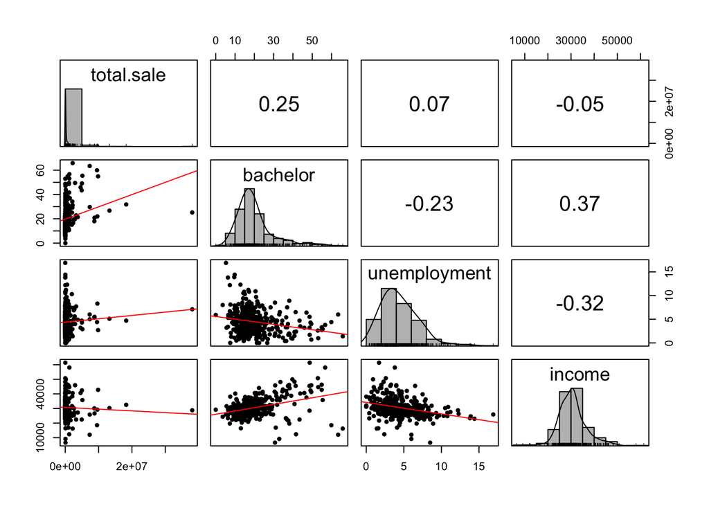

```r
pairs.panels(
  cities_data.clean.2[
    , c("total.sale", "bachelor",  "unemployment", "income")],
  hist.col = "grey",
  ellipses = FALSE,
  lm = TRUE ,
  cex.cor = 0.6
)
```

- Alcohol consumption and education level: The correlation coefficient between alcohol consumption and education level (bachelor’s degree) is 0.25, indicating a positive correlation. The scatter plot also suggests that as the proportion of people with higher education increases, alcohol consumption may increase, although the relationship is not strong.
- Alcohol consumption and unemployment: The correlation coefficient between alcohol consumption and unemployment is 0.07, showing a very weak positive correlation. Scatter plot of alcohol consumption also suggests that unemployment has a positive effect on the level of alcohol consumption but it is very weak.
- Alcohol consumption and income: The scatter plot between alcohol consumption and income indicates a very weak negative correlation (r = -0.05). This implies that income has almost no direct relationship with alcohol consumption, and as income increases, alcohol consumption has a slight downward trend.
- The distribution of alcohol consumption is severely right-skewed, while bachelor, unemployment, and income are slightly right-skewed